# Workflow: Physical Activity and Well-Being

Sofia Gil-Clavel

- Open the Data

```r
#### Opening the Data ####
DATA<-read.table("Replicability/DATA/cchs2012_mh.tab",sep="\t",header = TRUE)
```

- From the variable “PHSGAPA” (Moderate/vigorous physical activity -average/hours) drop those individuals whose content is “NOT STATED”.

```r
# The variable of interest is "PHSGAPA" 99.99 means "NOT STATED"
DATA<-DATA%>%filter(PHSGAPA<99)
```

- Transform the variable sex (DHH_SEX) into factor

```r
# Sex as Factor
DATA$DHH_SEX<-factor(DATA$DHH_SEX,
                    levels = c(1,2),
                    labels = c("MALE","FEMALE"))
```

- Create the variable “GROUP” by transforming “PHSGAPA” into the next categories:
  - “NOT” if they do 0 hours of exercise
  - “0%-25%” for those in the first quantile without considering those that do 0 hours of exercise.
  - “25-50” for those in the second quantile without considering those that do 0 hours of exercise.
  - “50-75” for those in the third quantile without considering those that do 0 hours of exercise.
  - “75-100” for those in the fourth quantile without considering those that do 0 hours of exercise.

```r
#### Those that do not exercise
NOTex<-DATA%>%filter(PHSGAPA==0)

NOTex$GROUPS<-"NOT"

#### Those that DO exercise
DOex<-DATA%>%filter(PHSGAPA>0)
# hist(DOex$PHSGAPA,freq = FALSE)

DOex$GROUPS <- with(DOex, cut(PHSGAPA,
                      breaks = qu <- quantile(PHSGAPA),
                      labels = paste0(names(qu)[-5],"-",names(qu)[-1]),
                      include.lowest=TRUE))

#### Join
ALL<-rbind(NOTex,DOex)
```

- Create a table that shows the percentage of population in each “GROUP” by age-groups breaking down by sex.

```r
#### Some Basic Demogs ####
# DHH_SEX: MALE(1) & FEMALE(2)
# DHHGAGE: Age - grouped variable
A1<-seq(15,80,5)
A2<-A1+4; A2[length(A2)]="more"
Alabels<-paste0(A1,"-",A2)

ALL$DHHGAGE<-factor(ALL$DHHGAGE,
                     levels = 1:14,
                     labels = Alabels)

TABLE=ALL%>%
  group_by(GROUPS,DHHGAGE,DHH_SEX)%>%
  count(DHHGAGE,DHH_SEX)%>%
  ungroup()%>%
  group_by(GROUPS,DHH_SEX)%>%
  mutate(perc=100*n/sum(n))# %>%
# select(-n)%>%
# spread(GROUPS,perc)
```

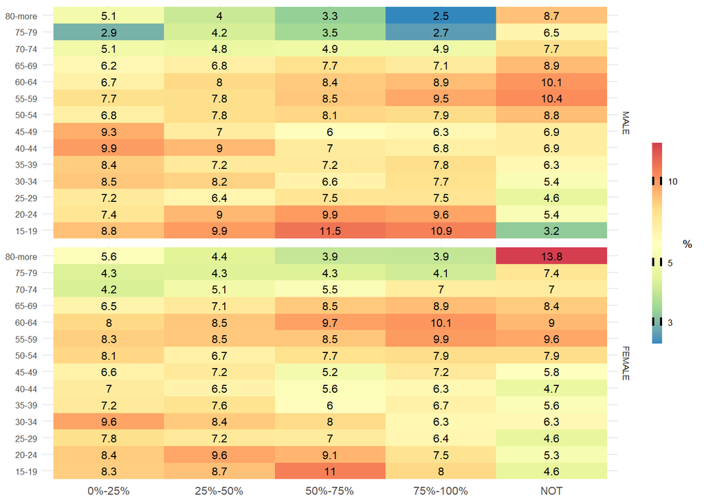

```r
(TABLE%>%
    ggplot() +
    geom_tile(aes(GROUPS,DHHGAGE,fill= perc))+
    geom_text(aes(GROUPS,DHHGAGE,label = round(perc, 1)),size=2.8) +
    facet_grid(DHH_SEX~.)+
    theme_minimal(base_size = 8)+
    theme(axis.text.x = element_text(hjust = 0.5,size = 8),
          axis.title = element_blank(),
          legend.position= "right",
          plot.caption = element_text(hjust =1,size = 8))+
    scale_fill_distiller(palette = "Spectral",trans = 'log10')+
    guides(fill=guide_colorbar(title = "%",
                               title.position = "right",
                               title.hjust = 0.5,
                               barwidth = 0.5, barheight = 10,
                               ticks.colour = "black",
                               ticks.linewidth = 8,ticks = TRUE)))
```

- Transform to NA all the values in “GEN_02A2”,“GEN_04”,“GEN_07”, and “GEN_10” that correspond to responds: “DON’T KNOW”, “REFUSAL”, and “NOT STATED”.

```r
VARIABLES<-c("GEN_02A2","GEN_04","GEN_07","GEN_10")

DATA2<-DATA%>%
  select(c("PHSGAPA","DHH_SEX","DHHGAGE",
           "GEN_02A2","GEN_04","GEN_07","GEN_10","GENDHDI"))

#### Transform "NOT STATED" into NA ####
# GEN_02A2: Satisfaction with life in general - 11 point scale GEN 11
DATA2<-DATA2%>%mutate(GEN_02A2=ifelse(GEN_02A2<97,GEN_02A2,NA))
# GEN_04: Frequency - trouble sleeping GEN 10
DATA2<-DATA2%>%mutate(GEN_04=ifelse(GEN_04<7,GEN_04,NA))
# GEN_07: Perceived life stress GEN 12
DATA2<-DATA2%>%mutate(GEN_07=ifelse(GEN_07<7,GEN_07,NA))
# GEN_10: Sense of belonging to local community GEN 14
DATA2<-DATA2%>%mutate(GEN_10=ifelse(GEN_10<7,GEN_10,NA))
# GENDHDI: Perceived health - (D) GEN 14
DATA2<-DATA2%>%mutate(GENDHDI=ifelse(GENDHDI<9,GENDHDI,NA))
```

- Run a linear model where the outcome is “PHSGAPA” and the independent variables are “DHH_SEX”,“DHHGAGE”, “GEN_02A2”,“GEN_04”,“GEN_07”,“GEN_10”, and “GENDHDI”.

```r
#### Running simple linear model ####
fit<-lm(PHSGAPA~.,data = DATA2)

SUM<-summary(fit)
```

- Report the results as a table (Table 1) with the coefficients and their 95% confidence intervals, standard errors, p-values, and the standard p-value< ’*’ coding. Also rename the variables into more descriptive names:
  - DHH_SEXFEMALE: “Sex:Female”
  - DHHGAGE: “Age”
  - GEN_02A2: “Satif. Life”
  - GEN_04: “Trob. Sleep.”
  - GEN_07: “Life Stress”
  - GEN_10: “Sense Belong.”
  - GENDHDI: “Health”

```r
Coef<-coef(fit)

# Confidence Interval
conf<-confint(fit)
CI1<-data.frame(lower=round(conf[,1],4),
                mean=round(Coef,4),
                upper=round(conf[,2],4))
# SE
CI1$SE<-SUM$coefficients[,2]
# p-values
p <- SUM$coefficients[,4]
CI1$`p-value`=round(p,digits = 4)
CI1$NAMES=row.names(CI1)

CI<-rbind(CI1)
CI$`p-value<`<-c("***","**","*","."," ")[findInterval(CI$`p-value` ,
                                        sort(c(1, 0.1, 0.05, 0.01, 0.001, 0))) ]

CI<-CI[-1,]

CI$NAMES<-factor(CI$NAMES,
                 levels = rev(CI$NAMES),
                 labels = rev(c("Sex:Female","Age","Satif. Life","Trob. Sleep.",
                            "Life Stress","Sense Belong.","Health")))

CI<-CI[,c(6,1:5,7)]

row.names(CI)<-NULL
```

```r
kableExtra::kbl(CI, booktabs = T, caption="Results Liner Model") #%>%
```

Results Liner Model

| NAMES | lower | mean | upper | SE | p-value | p-value< |
| --- | --- | --- | --- | --- | --- | --- |
| Sex:Female | -1.3546 | -1.2545 | -1.1544 | 0.0510510 | 0.0000 | *** |
| Age | -0.0941 | -0.0808 | -0.0675 | 0.0067900 | 0.0000 | *** |
| Satif. Life | 0.0432 | 0.0770 | 0.1109 | 0.0172717 | 0.0000 | *** |
| Trob. Sleep. | -0.0220 | 0.0216 | 0.0651 | 0.0222102 | 0.3314 |  |
| Life Stress | -0.0938 | -0.0395 | 0.0147 | 0.0276776 | 0.1531 |  |
| Sense Belong. | -0.2799 | -0.2213 | -0.1626 | 0.0299329 | 0.0000 | *** |
| Health | 0.5083 | 0.5639 | 0.6194 | 0.0283423 | 0.0000 | *** |

```r
  # kableExtra::kable_styling(position = "center")
```

- Plot the results

[figure not shown]

```r
#### Plotting the result ####
ggplot(CI, aes(x=NAMES, y=mean,label=`p-value<`)) +
   geom_errorbar(aes(ymin=lower, ymax=upper), width=.5,position = position_dodge(1)) +
   geom_point(size=2,position = position_dodge(1))+
   coord_flip()+
   scale_x_discrete(labels = levels(CI$NAMES), breaks=levels(CI$NAMES),
                    expand = c(0.1,0.1))+
   geom_hline(yintercept = 0, linetype="dashed",color="red")+
   theme(panel.spacing = unit(1, "lines"),
         axis.title.x = element_blank(),
         axis.title.y = element_blank(),
         legend.position = "top",text = element_text(size = 10),
         panel.background = element_rect(fill = "white"),
         panel.grid.major.y = element_line(size = 0.25,
                                           linetype = 'dashed',
                                           colour = "gray"),
         panel.grid.major.x = element_line(size = 0.25,
                                           linetype = 'dashed',
                                           colour = "gray"),
         strip.background = element_rect(color = NA,
                                         fill = NA, size = 1),
         axis.line = element_line(color = 'black'),
         plot.caption = element_text(hjust = 0.5,size = 10))+
   geom_text(hjust=0, vjust=0,size=8,position = position_dodge(1))
```